# Solving non linear equations

- The following weeks we will consider methods for solving nonlinear equations.
- Given a nonlinear function $f(x)$, we seek a value of $x$ for which

$$f(x) = 0.$$

Such a solution value for $x$ is called a **root** of the equation, and a **zero** of the function f(x). An example of a nonlinear equation with one variable is

$$f(x) = x^2 - 4 sin(x) = 0.$$

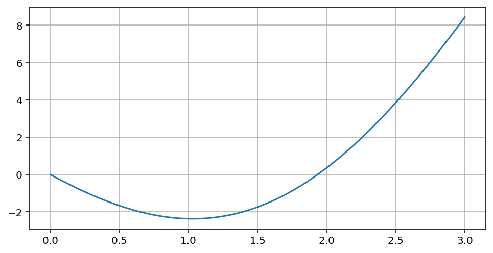

```python
import numpy as np
import matplotlib.pyplot as plt

x = np.linspace(0, 3, 100)
y = x**2 - 4*np.sin(x)

plt.figure(figsize=(8,4))
plt.grid()
plt.plot(x,y)
```

- As can be seen from the figure above, the function has roots at 0.0 and near 1.9. Graphical examination of a function is often a good way to find the neighborhood of roots.
- Graphical techniques are of limited practical value because they are not precise.
- However, graphical methods can be utilized to obtain rough estimates of roots. These estimates can be employed as starting guesses for numerical methods discussed in this chapter.

## Solving an equation of one variable $f(x) = 0$

- The methods used for solving this type of equation numerically can be divided into two major groups: **bracketing methods**, and **open methods**.
- In **bracketing methods** such as the **bisection method** and the **regula falsi method**, an interval that includes the solution is identified.
- By definition, the end points of the interval are the upper and lower bound of the solution. Then, by using a numerical scheme, the size of the interval is successively reduced until the distance between the end points is less than the desired accuracy of the solution.
- In the **open methods**, such as **Newton's method, secant method or fixed point iteration method**, an initial estimate for the solution is assumed.
- The value of this initial guess should be close to the actual solution. Then, by using a numerical scheme, better (more accurate) values for the solution are calculated.
- **Bracketing methods** always converge to the solution. **Open methods** are usually more efficient but sometimes might not yield the solution.

## Bracketing methods

### Bisection method

1.Choose the first interval by finding points $a$ and $b$ such that a solution exists between them. This means that $f(a)$ and $f(b)$ have different signs such that $f(a) \cdot f(b) < 0$. The points can be determined by examining the plot of versus $x$.

2.Calculate the first estimate of the numerical solution $x_{NS1}=\frac{a+b}{2}$.

3.Determine whether the true solution is between a and xNS1, or between xNS1 and b. This is done by checking the sign of the product of $f(a) \cdot f(x_{NS1})$:

- If $f(a) \cdot f(x_{NS1}) < 0$, the true solution is between $a$ and $x_{NS1}$.
- If $f(a) \cdot f(x_{NS1}) > 0$, the true solution is between $x_{NS1}$ and $b$.

4.Select the subinterval that contains the true solution ($a$ to $x_{NS1}$, or $x_{NS1}$ to $b$) as the new interval $[a, b]$, and go back to **step 2**.

5.Steps 2 through 4 are repeated until a specified tolerance or error bound is attained.

### Graphical depiction of the bisection method

[figure not shown]

### Termination criteria

1.If it is known that the solution is within the domain $[a, b]$, then the numerical solution can be taken as $(a+b)/2$, and the tolerance ($\epsilon_a$) to be half the distance between $a$ and $b$. The iteration is ended if the tolerance of the iteration is smaller than the desired tolerance.

$$root = \frac{a+b}{2}\pm \epsilon_a, \quad \epsilon_a = \left|\frac{b-a}{2}\right|, \quad \epsilon_a \leq \epsilon_s. $$

2.An alternative to this is to terminate the method when the estimated relative as defined next is less than a predefined value.

$$estimated\ relative\ error\ =\frac{|x_{NS}^{(n)} - x_{NS}^{(n-1)}|}{|x_{NS}^{(n)}|} $$

- When the estimated numerical solutions are close to the true solution, it is anticipated that the difference $x_{NS}^{(n)} - x_{NS}^{(n-1)}$, in absolute value, is small compared to the absolute value of $x_{NS}^{(n)}$, and the Estimated Relative Error is approximately the same as the True Relative Error.

### Algorithm

```
INPUT: Function f,
       endpoint values a, b,
       tolerance TOL,
       maximum iterations NMAX
CONDITIONS: a < b,
            either f(a) < 0 and f(b) > 0 or f(a) > 0 and f(b) < 0
OUTPUT: value which differs from a root of f(x) = 0 by less than TOL

N ← 1
while N ≤ NMAX do // limit iterations to prevent infinite loop
    c ← (a + b)/2 // new midpoint
    if f(c) = 0 or (b – a)/2 < TOL then // solution found
        Output(c)
        Stop
    end if
    N ← N + 1 // increment step counter
    if sign(f(c)) = sign(f(a)) then a ← c else b ← c // new interval
end while
Output("Method failed.") // max number of steps exceeded
```

### Addtional notes

- The method always converges to an answer, provided a root was trapped in the interval to begin with.
- The method may fail when the function is tangent to the axis and does not cross the x-axis at $f(x)=0$.
- The method converges slowly relative to other methods.

See: https://peterjgagnon.wordpress.com/2009/11/10/bisection-method/

### Bisection method example:

- Suppose that the bisection method is used to find a root of the polynomial $$f(x)=x^{3}-x-2.$$
- First, two numbers $a$ and $b$ have to be found such that $f(a)$ and $f(b)$ have opposite signs.
  - For the above function, $a=1$ and $b=2$ satisfy this criterion, as $$f(1)=(1)^{3}-(1)-2=-2$$ and $$f(2)=(2)^{3}-(2)-2=+4.$$
- Because the function is continuous, there must be a root within the interval $[1, 2]$.

See:

- https://en.wikipedia.org/wiki/Bisection_method
- https://math.stackexchange.com/questions/1166256/bisection-method-guessing-interval

## Regula Falsi method

- The convergence process in the bisection method is very slow. It depends only on the choice of end points of the interval $[a,b]$.
  - The function $f(x)$ does not have any role in finding the next approximation (which is just the mid-point of $a$ and $b$), it is used only to decide the next smaller interval $[a,c]$ or $[c,b]$.
  - For example, if $f(a)$ is much closer to zero than $f(b)$, it is likely that the root is closer to $a$ than to $b$.
  - A better approximation to next estimate can be obtained by taking the straight line joining the points ($a,\ f(a)$) and ($b,\ f(b)$) intersecting the x-axis. To obtain the value of next approximation $X_{NS}$

$$X_{NS} = \frac{a \cdot f(b) - b \cdot f(a)}{f(b) - f(a)}$$

- The new interval to consider is either $[a,X_{NS}]$ or $[X_{NS},b]$ depending on whether $f(a) \cdot f(X_{NS}) < 0$ or $f (b) \cdot f (X_{NS}) < 0$. the process is then repeated until the numerical solution is deemed accurate enough.

### Algorithm for the Regula Falsi method

Identical to the one for the bisection except that

$$X_{NS} = \frac{a \cdot f(b) - b \cdot f(a)}{f(b) - f(a)}$$

- **Termination Criteria:** same stopping criterion as in the bisection method
- Graphical depiction of the the method

[figure not shown]

### Additional notes

- The method always converges to an answer, provided a root was trapped in the interval $[a, b]$.
- Frequently, as in the case shown in the grapical depiction, the function in the interval is either concave up or concave down. In this case, one of the endpoints of the interval stays the same in all the iterations, while the other endpoint advances toward the root.
- In other words, the numerical solution advances toward the root only from one side. The convergence toward the solution could be faster if the other endpoint would also move toward the root.
- Several modifications have been introduced to the regula falsi method that make the subinterval in successive iterations approach the root from both sides.

## Regula falsi method example

- Find the root of $$f (x) = cos(x) - x3 = 0.$$
- Use the following interval $[0, 1]$.
- See: https://en.wikipedia.org/wiki/Regula_falsi

## Open Methods

- Newton-Raphson method.
- Secant method.
- Fixed-Point iteration method.

### Newton's method

- The most widely used of all root-locating formulas is the **Newton-Raphson** method.
- If the initial guess at the root is $x_n$, a tangent can be extended from the point $[x_n, f(x_n)]$.
- The point where this tangent crosses the $x-axis$ usually represents an improved estimate of the root.
- The Newton-Raphson method can be derived on the basis of this geometrical interpretation

[figure not shown]

### Algorithm for Newton's Method

The equation of the tangent line to the curve $y = f(x)$ at $x = x_n$ is $$y=f'(x_{n})\,(x-x_{n})+f(x_{n}),$$ where $f'$ denotes the derivative.

The x-intercept of this line (the value of $x$ which makes $y = 0$) is taken as the next approximation, $x_n + 1$, to the root, so that the equation of the tangent line is satisfied when ${ (x,y)=(x_{n+1},0)}$: $$0=f'(x_{n})\,(x_{n+1}-x_{n})+f(x_{n}).$$ Solving for $x_{n + 1}$ gives

$${ x_{n+1}=x_{n}-{\frac {f(x_{n})}{f'(x_{n})}}.}$$

1. Choose a point $x_1$ as an initial guess of the solution.
2. For $n=1, 2,...$ until the error is smaller than a specified value, calculate $x_{n+1}$ by using the previous equation.

### Termination Criteria

- In practice, the iterations are stopped when an estimated error is smaller than some predetermined value.
- A tolerance in the solution, as in the bisection method, cannot be calculated since bounds are not known.
- Two error estimates that are typically used with Newtons method are:
1. Estimated relative error: The iterations are stopped when the estimated relative error is smaller than a specified value $\epsilon_s$

$$\frac{|x_{NS}^{(n)} - x_{NS}^{(n-1)}|}{|x_{NS}^{(n)}|} < \epsilon_s$$

1. Tolerance in $f(x)$: the iterations are stopped when the absolute value of $f(X_{NS})$ is smaller than some number $\delta$.

$$|f(X_{NS})| < \delta $$

### Additional notes

- Newton's method can be derived using Taylor series (see: https://en.wikipedia.org/wiki/Newton%27s_method).
- Convergence problems typically occur when the value of $f'(x)$ is close to zero in the vicinity of the solution.
- There is no general convergence criterion for Newton-Raphson. Its convergence depends on the nature of the function and on the accuracy of the initial guess.
- The only remedy is to have an initial guess that is sufficiently close to the root. And for some functions, no guess will work!
- Good guesses are usually predicated on knowledge of the physical problem setting or on devices such as graphs that provide insight into the behavior of the solution.
- A function $f'(x)$ has to be substituted in the iterative formula.

## Secant method

- The secant method uses two points in the neighborhood of the solution to determine a new estimate for the solution.
- The two points (marked as $x_1$ and $x_2$ in the figure) are used to define a straight line (secant line), and the point where the line intersects the x-axis (marked as $x_3$ in the figure) is the new estimate for the solution.
- As shown, the two points can be on one side of the solution or the solution can be between the two points.

[figure not shown]

- The slope of the secant line is given by:

$$\frac{f(x_2) - f(x_1)}{x_2 - x_1} = \frac{f(x_2)-f(x_3)}{x_2 - x_3}$$

- Solving for $x_3$:

$$x_3 = x_2 − \frac{f(x_2)} {\frac{f(x_2) − f(x_1)}{x_2 − x_1}}$$

[figure not shown]

- The algorithm repeat the process, i.e.: uses $x_2$ and $x_3$ to produce another secant line, and then use its root to approximate the solution.
- This yields the general iteration formula

$$x_{n+1} = x_n − \frac{f(x_n)} {\frac{f(x_n) − f(x_{n-1})}{x_n − x_{n-1}}}$$

### Additional notes

- When the two points that define the secant line are close to each other, the method approximates Newton's method.

$$x_{n+1} = x_n − \frac{f(x_n)} {\frac{f(x_n) − f(x_{n-1})}{x_n − x_{n-1}}} \approx x_n - \frac{f(x_n)}{f'(x_n)}$$

- Unlike Newton's method, it is not necessary to know the analytical form of $f'(x)$.

## Fixed-Point iteration method

Open methods employ a formula to predict the root. Such a formula can be developed for simple fixed-point iteration (or, as it is also called, one-point iteration or successive substitution) by rearranging the function $f(x)=0$ so that $x$ is on the left-hand side of the equation: $$x = g(x)$$

This transformation can be accomplished either by algebraic manipulation or by simply adding $x$ to both sides of the original equation. For example, $$x^2−2x+3=0$$ can be simply manipulated to yield $$x = \frac{x^2 + 3}{2}$$ whereas $sinx = 0$ could be put into the same form by adding $x$ to both sides to yield $x = sinx + x$.

The previous equations provide a formula to predict a new value of $x$ as a function of an old value of $x$. Thus, given an initial guess at the root $x_i$,the equation can be used to compute a new estimate $x_{i+1}$ as expressed by the iterative formula $$x_{i+1} = g(x_i)$$

When the method works, the values of x that are obtained are successive iterations that progressively converge toward the solution. Two such cases are illustrated graphically:

[figure not shown]

It is possible, however, that the iterations will not converge toward the fixed point, but rather diverge away. This is shown in the figure below. The figure shows that even though the starting point is close to the solution, the subsequent points are moving farther away from the solution:

[figure not shown]

For a given equation f(x) = 0, the iteration function is not unique since it is possible to change the equation into the form in different ways. This means that several iteration functions g(x) can be written for the same equation. A g(x) that should be used for the iteration process is one for which the iterations converge toward the solution. There might be more than one form that can be used, or it may be that none of the forms are appropriate so that the fixed-point iteration method cannot be used to solve the equation. In cases where there are multiple solutions, one iteration function may yield one root, while a different function yields other roots. Actually, it is possible to determine ahead of time if the iterations converge or diverge for a specific.

**The fixed-point iteration method converges if, in the neighborhood of the fixed point, the derivative of g(x) has an absolute value that is smaller than 1 (also called Lipschitz continuous):**

$$| g'(x) |< 1$$

**Additional note:** As with Newton's method, the iterations can be stopped either when the relative error or the tolerance in $f(x)$ is smaller than some predetermined value.

### Sources and resources

- https://en.wikipedia.org/wiki/Fixed_point_(mathematics)
- http://wwwf.imperial.ac.uk/metric/metric_public/numerical_methods/iteration/fixed_point_iteration.html
- https://homepage.divms.uiowa.edu/~whan/3800.d/S3-4.pdf
- http://home.iitk.ac.in/~psraj/mth101/lecture_notes/lecture8.pdf